# summary

### Step 3. Define functions to train and validate transormer model

```python
def train(model, opt, loss_fn, dataloader):
    """
    function to train the model for train dataset
    """
    model.train()
    total_loss = 0

    for batch in dataloader:
        X, y = batch[:, 0], batch[:, 1]
        X, y = torch.tensor(X).to(device), torch.tensor(y).to(device)

        # window size of inputes should be shifted by one to get the target value
        y_input = y[:,:-1]
        y_expected = y[:,1:]

        # get mask to mask out the next words
        sequence_length = y_input.size(1)
        tgt_mask = model.get_tgt_mask(sequence_length).to(device)

        # calculate predictions using inputs which are multiple batches of train set
        pred = model(X, y_input, tgt_mask)

        # change the shape of pred to have batch size first again
        pred = pred.permute(1, 2, 0)
        loss = loss_fn(pred, y_expected)

        # optimization, backward propagation to set the weights for each neuron in the model to get minimzie loss function
        opt.zero_grad()
        loss.backward()
        opt.step()

        total_loss += loss.detach().item()

    return total_loss / len(dataloader)
```

```python
def validation(model, loss_fn, dataloader):
    """
    function to validate the accuracy of the model
    """

    model.eval()
    total_loss = 0

    with torch.no_grad():
        for batch in dataloader:
            X, y = batch[:, 0], batch[:, 1]
            X, y = torch.tensor(X, dtype=torch.long, device=device), torch.tensor(y, dtype=torch.long, device=device)

            # we shift the target by one
            y_input = y[:,:-1]
            y_expected = y[:,1:]

            # get mask to mask out the next words
            sequence_length = y_input.size(1)
            tgt_mask = model.get_tgt_mask(sequence_length).to(device)

            # calculate predictions using inputs which are multiple batches of validation set
            pred = model(X, y_input, tgt_mask)

            # change the shape of pred to have batch size first again
            pred = pred.permute(1, 2, 0)
            loss = loss_fn(pred, y_expected)
            total_loss += loss.detach().item()

    return total_loss / len(dataloader)
```

```python
def fit(model, opt, loss_fn, train_dataloader, val_dataloader, epochs):
    """
    fit the model to train set and validation set, optimize parameters and calculate loss function
    """
    # Used for plotting later on
    train_loss_list, validation_loss_list = [], []

    for epoch in range(epochs):

        train_loss = train(model, opt, loss_fn, train_dataloader)
        train_loss_list += [train_loss]

        validation_loss = validation(model, loss_fn, val_dataloader)
        validation_loss_list += [validation_loss]

        print(f"Training loss: {train_loss:.4f}")
        print(f"Validation loss: {validation_loss:.4f}")

    return train_loss_list, validation_loss_list
```

### Step 4.1 Fit the model, learning rate of 0.001, 4 encoder layers and 4 decoder layers, 10 epoches

```python
device = "cuda" if torch.cuda.is_available() else "cpu"
model1 = Transformer(num_tokens=4, dim_model=8, num_heads=2, num_encoder_layers=4, num_decoder_layers=4, dropout_p=0.1).to(device)
opt = torch.optim.SGD(model1.parameters(), lr=0.001)
loss_fn = nn.CrossEntropyLoss()
```

```python
train_loss1, validation_loss1 = fit(model1, opt, loss_fn, train_dataloader, val_dataloader, 10)
```

```
Training loss: 1.0004
Validation loss: 0.8109
Training loss: 0.7734
Validation loss: 0.6954
Training loss: 0.6971
Validation loss: 0.6476
Training loss: 0.6599
Validation loss: 0.6188
Training loss: 0.6282
Validation loss: 0.5790
Training loss: 0.5777
Validation loss: 0.4883
Training loss: 0.5163
Validation loss: 0.4450
Training loss: 0.4798
Validation loss: 0.4333
Training loss: 0.4601
Validation loss: 0.4258
Training loss: 0.4507
Validation loss: 0.4220
```

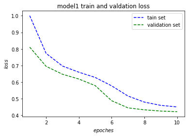

```python
x_points = np.arange(1,11)
plt.title('model1 train and valdation loss')
plt.plot(x_points, train_loss1, 'b--', label = 'tain set')
plt.plot(x_points, validation_loss1, 'g--', label = 'validation set')
plt.xlabel('$epoches$')
plt.ylabel('$loss$')
plt.legend(loc = 'upper right')
plt.show();
```

### 4.2 Fit the model, learning rate of 0.01, 2 encoder layers and 2 decoder layers, 10 epoches

```python
device = "cuda" if torch.cuda.is_available() else "cpu"
model2 = Transformer(num_tokens=4, dim_model=8, num_heads=2, num_encoder_layers=2, num_decoder_layers=2, dropout_p=0.1).to(device)
opt = torch.optim.SGD(model2.parameters(), lr=0.01)
loss_fn = nn.CrossEntropyLoss()
```

```python
train_loss2, validation_loss2 = fit(model2, opt, loss_fn, train_dataloader, val_dataloader, 10)
```

```
Training loss: 0.5584
Validation loss: 0.4182
Training loss: 0.4240
Validation loss: 0.3942
Training loss: 0.4026
Validation loss: 0.3753
Training loss: 0.3803
Validation loss: 0.3412
Training loss: 0.3525
Validation loss: 0.3034
Training loss: 0.3299
Validation loss: 0.2736
Training loss: 0.3129
Validation loss: 0.2556
Training loss: 0.2976
Validation loss: 0.2360
Training loss: 0.2887
Validation loss: 0.2252
Training loss: 0.2781
Validation loss: 0.2160
```

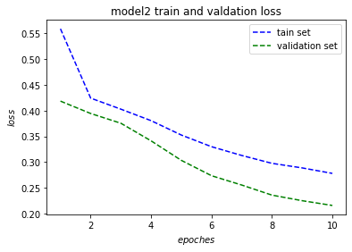

```python
x_points = np.arange(1,11)
plt.title('model2 train and valdation loss')
plt.plot(x_points, train_loss2, 'b--', label = 'tain set')
plt.plot(x_points, validation_loss2, 'g--', label = 'validation set')
plt.xlabel('$epoches$')
plt.ylabel('$loss$')
plt.legend(loc = 'upper right')
plt.show();
```

### Step 4.3 Fit the model, learning rate of 0.1, 2 encoder layers and 4 decoder layers, 10 epoches

```python
device = "cuda" if torch.cuda.is_available() else "cpu"
model3 = Transformer(num_tokens=4, dim_model=8, num_heads=2, num_encoder_layers=2, num_decoder_layers=4, dropout_p=0.1).to(device)
opt = torch.optim.SGD(model3.parameters(), lr=0.1)
loss_fn = nn.CrossEntropyLoss()
```

```python
train_loss3, validation_loss3 = fit(model3, opt, loss_fn, train_dataloader, val_dataloader, 10)
```

```
Training loss: 0.3830
Validation loss: 0.3120
Training loss: 0.2797
Validation loss: 0.2035
Training loss: 0.2487
Validation loss: 0.2256
Training loss: 0.2335
Validation loss: 0.1530
Training loss: 0.2219
Validation loss: 0.1483
Training loss: 0.2121
Validation loss: 0.1362
Training loss: 0.2036
Validation loss: 0.1231
Training loss: 0.2041
Validation loss: 0.1281
Training loss: 0.1904
Validation loss: 0.1269
Training loss: 0.1818
Validation loss: 0.1048
```

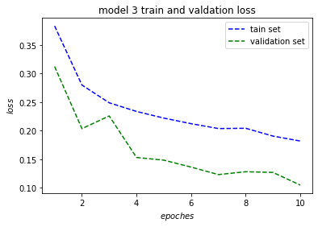

```python
x_points = np.arange(1,11)
plt.title('model 3 train and valdation loss')
plt.plot(x_points, train_loss3, 'b--', label = 'tain set')
plt.plot(x_points, validation_loss3, 'g--', label = 'validation set')
plt.xlabel('$epoches$')
plt.ylabel('$loss$')
plt.legend(loc = 'upper right')
plt.show();
```

## Further steps:

1. Collect more data
2. Make the model generative
3. Explore the way that Alphafold2 evaluate the proteins and impalement it